# Module2

```python
import datashader as ds
import datashader.transfer_functions as tf
import datashader.glyphs
from datashader import reductions
from datashader.core import bypixel
from datashader.utils import lnglat_to_meters as webm, export_image
from datashader.colors import colormap_select, Greys9, viridis, inferno
import copy

from pyproj import Proj, transform
import numpy as np
import pandas as pd
import urllib
import json
import datetime
import colorlover as cl

import plotly.plotly as py
import plotly.graph_objs as go
from plotly import tools
import plotly.figure_factory as ff

%matplotlib inline
import seaborn as sns
import matplotlib.pyplot as plt
from matplotlib import style
style.use('fivethirtyeight')

from shapely.geometry import Point, Polygon, shape
from functools import partial
from IPython.display import GeoJSON
```

For module 2 we'll be looking at techniques for dealing with big data. In particular binning strategies and the datashader library (which possibly proves we'll never need to bin large data for visualization ever again.)

To demonstrate these concepts we'll be looking at the PLUTO dataset put out by New York City's department of city planning. PLUTO contains data about every tax lot in New York City.

PLUTO data can be downloaded from [here](https://www1.nyc.gov/site/planning/data-maps/open-data/dwn-pluto-mappluto.page). Unzip them to the same directory as this notebook, and you should be able to read them in using this (or very similar) code. Also take note of the data dictionary, it'll come in handy for this assignment.

```python
bk = pd.read_csv('PLUTO_for_WEB/BK_18v1.csv')
bx = pd.read_csv('PLUTO_for_WEB/BX_18v1.csv')
mn = pd.read_csv('PLUTO_for_WEB/MN_18v1.csv')
qn = pd.read_csv('PLUTO_for_WEB/QN_18v1.csv')
si = pd.read_csv('PLUTO_for_WEB/SI_18v1.csv')

ny = pd.concat([bk, bx, mn, qn, si], ignore_index=True)

# Getting rid of some outliers
ny = ny[(ny['YearBuilt'] > 1850) & (ny['YearBuilt'] < 2020) & (ny['NumFloors'] != 0)]
```

I'll also do some prep for the geographic component of this data, which we'll be relying on for datashader.

You're not required to know how I'm retrieving the lattitude and longitude here, but for those interested: this dataset uses a flat x-y projection (assuming for a small enough area that the world is flat for easier calculations), and this needs to be projected back to traditional lattitude and longitude.

```python
wgs84 = Proj("+proj=longlat +ellps=GRS80 +datum=NAD83 +no_defs")
nyli = Proj("+proj=lcc +lat_1=40.66666666666666 +lat_2=41.03333333333333 +lat_0=40.16666666666666 +lon_0=-74 +x_0=300000 +y_0=0 +ellps=GRS80 +datum=NAD83 +to_meter=0.3048006096012192 +no_defs")
ny['XCoord'] = 0.3048*ny['XCoord']
ny['YCoord'] = 0.3048*ny['YCoord']
ny['lon'], ny['lat'] = transform(nyli, wgs84, ny['XCoord'].values, ny['YCoord'].values)

ny = ny[(ny['lon'] < -60) & (ny['lon'] > -100) & (ny['lat'] < 60) & (ny['lat'] > 20)]

#Defining some helper functions for DataShader
background = "black"
export = partial(export_image, background = background, export_path="export")
cm = partial(colormap_select, reverse=(background!="black"))
```

## Part 1: Binning and Aggregation

Binning is a common strategy for visualizing large datasets. Binning is inherent to a few types of visualizations, such as histograms and [2D histograms](https://plot.ly/python/2D-Histogram/) (also check out their close relatives: [2D density plots](https://plot.ly/python/2d-density-plots/) and the more general form: [heatmaps](https://plot.ly/python/heatmaps/).

While these visualization types explicitly include binning, any type of visualization used with aggregated data can be looked at in the same way. For example, lets say we wanted to look at building construction over time. This would be best viewed as a line graph, but we can still think of our results as being binned by year:

```python
trace = go.Scatter(
    # I'm choosing BBL here because I know it's a unique key.
    x = ny.groupby('YearBuilt').count()['BBL'].index,
    y = ny.groupby('YearBuilt').count()['BBL']
)

layout = go.Layout(
    xaxis = dict(title = 'Year Built'),
    yaxis = dict(title = 'Number of Lots Built')
)

fig = go.Figure(data = [trace], layout = layout)

py.iplot(fig, filename = 'ny-year-built')
```

[interactive chart not shown]

Something looks off... You're going to have to deal with this imperfect data to answer this first question.

But first: some notes on pandas. Pandas dataframes are a different beast than R dataframes, here are some tips to help you get up to speed:

Hello all, here are some pandas tips to help you guys through this homework:

[Indexing and Selecting](https://pandas.pydata.org/pandas-docs/stable/indexing.html): .loc and .iloc are the analogs for base R subsetting, or filter() in dplyr

[Group By](https://pandas.pydata.org/pandas-docs/stable/groupby.html): This is the pandas analog to group_by() and the appended function the analog to summarize(). Try out a few examples of this, and display the results in Jupyter. Take note of what's happening to the indexes, you'll notice that they'll become hierarchical. I personally find this more of a burden than a help, and this sort of hierarchical indexing leads to a fundamentally different experience compared to R dataframes. Once you perform an aggregation, try running the resulting hierarchical datafrome through a [reset_index()](https://pandas.pydata.org/pandas-docs/stable/generated/pandas.DataFrame.reset_index.html).

[Reset_index](https://pandas.pydata.org/pandas-docs/stable/generated/pandas.DataFrame.reset_index.html): I personally find the hierarchical indexes more of a burden than a help, and this sort of hierarchical indexing leads to a fundamentally different experience compared to R dataframes. reset_index() is a way of restoring a dataframe to a flatter index style. Grouping is where you'll notice it the most, but it's also useful when you filter data, and in a few other split-apply-combine workflows. With pandas indexes are more meaningful, so use this if you start getting unexpected results.

Indexes are more important in Pandas than in R. If you delve deeper into the using python for data science, you'll begin to see the benefits in many places (despite the personal gripes I highlighted above.) One place these indexes come in handy is with time series data. The pandas docs have a [huge section](http://pandas.pydata.org/pandas-docs/stable/timeseries.html) on datetime indexing. In particular, check out [resample](https://pandas.pydata.org/pandas-docs/stable/generated/pandas.DataFrame.resample.html), which provides time series specific aggregation.

[Merging, joining, and concatenation](https://pandas.pydata.org/pandas-docs/stable/merging.html): There's some overlap between these different types of merges, so use this as your guide. Concat is a single function that replaces cbind and rbind in R, and the results are driven by the indexes. Read through these examples to get a feel on how these are performed, but you will have to manage your indexes when you're using these functions. Merges are fairly similar to merges in R, similarly mapping to SQL joins.

Apply: This is explained in the "group by" section linked above. These are your analogs to the plyr library in R. Take note of the lambda syntax used here, these are anonymous functions in python. Rather than predefining a custom function, you can just define it inline using lambda.

Browse through the other sections for some other specifics, in particular reshaping and categorical data (pandas' answer to factors.) Pandas can take a while to get used to, but it is a pretty strong framework that makes more advanced functions easier once you get used to it. Rolling functions for example follow logically from the apply workflow (and led to the best google results ever when I first tried to find this out and googled "pandas rolling")

Google Wes Mckinney's book "Python for Data Analysis," which is a cookbook style intro to pandas. It's an O'Reilly book that should be pretty available out there.

### Question

After a few building collapses, the City of New York is going to begin investigating older buildings for safety. The city is particularly worried about buildings that were unusually tall when they were built, since best-practices for safety hadn’t yet been determined. Create a graph that shows how many buildings of a certain number of floors were built in each year (note: you may want to use a log scale for the number of buildings). Find a strategy to bin buildings (It should be clear 20-29-story buildings, 30-39-story buildings, and 40-49-story buildings were first built in large numbers, but does it make sense to continue in this way as you get taller?)

```python
# First check frequencies for the `NumFloors`
ny['NumFloors'].value_counts().sort_values(ascending=False)
```

```
2.00      414659
3.00      119588
2.50       82038
1.00       76121
4.00       27564
1.50       23229
5.00       16601
2.75       13360
6.00       12254
1.67        8448
1.75        5013
7.00        2223
8.00        1111
3.50        1003
12.00        897
9.00         716
10.00        547
16.00        476
13.00        463
14.00        425
11.00        419
15.00        416
20.00        276
4.50         253
2.67         233
17.00        227
19.00        193
21.00        181
18.00        158
3.75         144
           ...
62.00          1
13.50          1
28.50          1
1.78           1
5.25           1
69.00          1
114.00         1
2.20           1
72.00          1
2.87           1
119.00         1
5.09           1
18.50          1
75.00          1
1.17           1
1.15           1
32.50          1
77.00          1
35.50          1
1.35           1
6.75           1
1.31           1
78.00          1
104.00         1
2.90           1
2.10           1
2.77           1
1.99           1
1.01           1
102.00         1
Name: NumFloors, Length: 166, dtype: int64
```

```python
ny['NumFloors'].describe()
```

```
count    811134.000000
mean          2.442989
std           1.915653
min           0.500000
25%           2.000000
50%           2.000000
75%           2.500000
max         119.000000
Name: NumFloors, dtype: float64
```

> As the instruction suggests, it is clear that the binning is absolutely necessary. The column `NumFloors` contains partial floors, such as, 1.35 or 6.75 floors. We will bin them using pd.cut to rounding down tens value.

```python
copy = ny.copy()
print(ny.shape)
print(copy.shape)
```

```
(811134, 91)
(811134, 91)
```

```python
bins = [0, 10, 20, 30, 40, 50, 60, 70, 80, 90, 100, 110, 120]
labels = ['0-9', '10-19', '20-29', '30-39', '40-49', '50-59', '60-69', '70-79', '80-89', '90-99', '100-109', '110-120']
copy['NumFloorsGroup'] = pd.cut(copy['NumFloors'], bins=bins, labels=labels, include_lowest=True)
table = copy.groupby(['YearBuilt', 'NumFloorsGroup', 'NumFloors'])

floors = pd.DataFrame()
floors['Count'] = table['NumFloors'].count()
unstack = floors.groupby(['YearBuilt','NumFloorsGroup']).sum()['Count'].unstack(level=-1)
unstack.fillna(0).astype(int)
```

| NumFloorsGroup YearBuilt | 0-9 | 10-19 | 20-29 | 30-39 | 40-49 | 50-59 | 60-69 | 70-79 | 80-89 | 100-109 | 110-120 |
| --- | --- | --- | --- | --- | --- | --- | --- | --- | --- | --- | --- |
| 1851 | 8 | 0 | 0 | 0 | 0 | 0 | 0 | 0 | 0 | 0 | 0 |
| 1852 | 14 | 0 | 0 | 0 | 0 | 0 | 0 | 0 | 0 | 0 | 0 |
| 1853 | 11 | 1 | 0 | 0 | 0 | 0 | 0 | 0 | 0 | 0 | 0 |
| 1854 | 6 | 0 | 0 | 0 | 0 | 0 | 0 | 0 | 0 | 0 | 0 |
| 1855 | 14 | 0 | 0 | 0 | 0 | 0 | 0 | 0 | 0 | 0 | 0 |
| 1856 | 11 | 0 | 0 | 0 | 0 | 0 | 0 | 0 | 0 | 0 | 0 |
| 1857 | 8 | 0 | 0 | 0 | 0 | 0 | 0 | 0 | 0 | 0 | 0 |
| 1858 | 8 | 0 | 0 | 0 | 0 | 0 | 0 | 0 | 0 | 0 | 0 |
| 1859 | 10 | 0 | 0 | 0 | 0 | 0 | 0 | 0 | 0 | 0 | 0 |
| 1860 | 37 | 0 | 0 | 0 | 0 | 0 | 0 | 0 | 0 | 0 | 0 |
| 1861 | 3 | 0 | 0 | 0 | 0 | 0 | 0 | 0 | 0 | 0 | 0 |
| 1862 | 2 | 0 | 0 | 0 | 0 | 0 | 0 | 0 | 0 | 0 | 0 |
| 1863 | 3 | 0 | 0 | 0 | 0 | 0 | 0 | 0 | 0 | 0 | 0 |
| 1864 | 3 | 0 | 0 | 0 | 0 | 0 | 0 | 0 | 0 | 0 | 0 |
| 1865 | 8 | 0 | 0 | 0 | 0 | 0 | 0 | 0 | 0 | 0 | 0 |
| 1866 | 6 | 0 | 0 | 0 | 0 | 0 | 0 | 0 | 0 | 0 | 0 |
| 1867 | 5 | 0 | 0 | 0 | 0 | 0 | 0 | 0 | 0 | 0 | 0 |
| 1868 | 7 | 1 | 0 | 0 | 0 | 0 | 0 | 0 | 0 | 0 | 0 |
| 1869 | 12 | 0 | 0 | 0 | 0 | 0 | 0 | 0 | 0 | 0 | 0 |
| 1870 | 59 | 0 | 0 | 0 | 0 | 0 | 0 | 0 | 0 | 0 | 0 |
| 1871 | 20 | 0 | 0 | 0 | 0 | 0 | 0 | 0 | 0 | 0 | 0 |
| 1872 | 5 | 0 | 0 | 0 | 0 | 0 | 0 | 0 | 0 | 0 | 0 |
| 1873 | 5 | 0 | 0 | 0 | 0 | 0 | 0 | 0 | 0 | 0 | 0 |
| 1874 | 4 | 0 | 0 | 0 | 0 | 0 | 0 | 0 | 0 | 0 | 0 |
| 1875 | 15 | 0 | 0 | 0 | 0 | 0 | 0 | 0 | 0 | 0 | 0 |
| 1876 | 2 | 0 | 0 | 0 | 0 | 0 | 0 | 0 | 0 | 0 | 0 |
| 1877 | 1 | 0 | 0 | 0 | 0 | 0 | 0 | 0 | 0 | 0 | 0 |
| 1878 | 4 | 0 | 0 | 0 | 0 | 0 | 0 | 0 | 0 | 0 | 0 |
| 1879 | 3 | 0 | 0 | 0 | 0 | 0 | 0 | 0 | 0 | 0 | 0 |
| 1880 | 191 | 0 | 0 | 0 | 0 | 0 | 0 | 0 | 0 | 0 | 0 |
| ... | ... | ... | ... | ... | ... | ... | ... | ... | ... | ... | ... |
| 1989 | 3538 | 22 | 6 | 5 | 6 | 1 | 0 | 0 | 0 | 0 | 0 |
| 1990 | 3453 | 10 | 11 | 2 | 2 | 0 | 0 | 0 | 0 | 0 | 0 |
| 1991 | 2235 | 6 | 5 | 1 | 0 | 0 | 0 | 0 | 0 | 0 | 0 |
| 1992 | 3134 | 3 | 3 | 1 | 1 | 1 | 0 | 0 | 0 | 0 | 0 |
| 1993 | 2443 | 1 | 0 | 1 | 0 | 0 | 0 | 0 | 0 | 0 | 0 |
| 1994 | 2100 | 2 | 0 | 3 | 1 | 0 | 0 | 0 | 0 | 0 | 0 |
| 1995 | 2512 | 1 | 2 | 0 | 0 | 0 | 0 | 0 | 0 | 0 | 0 |
| 1996 | 3425 | 4 | 2 | 3 | 1 | 0 | 0 | 0 | 0 | 0 | 0 |
| 1997 | 3115 | 7 | 3 | 4 | 2 | 1 | 0 | 0 | 0 | 0 | 0 |
| 1998 | 2692 | 10 | 8 | 3 | 3 | 1 | 0 | 0 | 0 | 0 | 0 |
| 1999 | 3656 | 15 | 5 | 10 | 1 | 0 | 0 | 0 | 0 | 0 | 0 |
| 2000 | 4113 | 21 | 4 | 10 | 3 | 1 | 1 | 0 | 0 | 0 | 0 |
| 2001 | 4471 | 19 | 2 | 1 | 3 | 2 | 0 | 1 | 0 | 0 | 0 |
| 2002 | 4105 | 14 | 9 | 6 | 2 | 1 | 0 | 0 | 0 | 0 | 0 |
| 2003 | 4359 | 25 | 6 | 4 | 4 | 3 | 0 | 0 | 0 | 0 | 1 |
| 2004 | 6458 | 22 | 7 | 3 | 2 | 3 | 0 | 0 | 0 | 0 | 0 |
| 2005 | 5888 | 50 | 12 | 7 | 5 | 4 | 0 | 0 | 0 | 0 | 0 |
| 2006 | 4705 | 53 | 19 | 14 | 2 | 2 | 0 | 0 | 0 | 0 | 0 |
| 2007 | 3934 | 58 | 21 | 8 | 6 | 1 | 0 | 1 | 0 | 0 | 0 |
| 2008 | 2769 | 71 | 10 | 7 | 2 | 4 | 1 | 0 | 0 | 0 | 1 |
| 2009 | 1701 | 34 | 2 | 5 | 1 | 2 | 0 | 1 | 0 | 1 | 0 |
| 2010 | 1113 | 27 | 3 | 4 | 2 | 2 | 0 | 0 | 0 | 0 | 0 |
| 2011 | 1271 | 22 | 3 | 3 | 3 | 0 | 0 | 0 | 0 | 0 | 0 |
| 2012 | 1372 | 35 | 16 | 2 | 3 | 1 | 1 | 0 | 1 | 0 | 0 |
| 2013 | 1229 | 35 | 11 | 11 | 6 | 1 | 0 | 0 | 3 | 0 | 0 |
| 2014 | 1450 | 38 | 11 | 2 | 2 | 3 | 4 | 0 | 0 | 0 | 0 |
| 2015 | 1432 | 45 | 15 | 8 | 5 | 3 | 4 | 9 | 1 | 0 | 0 |
| 2016 | 1208 | 32 | 24 | 12 | 6 | 2 | 0 | 1 | 0 | 0 | 0 |
| 2017 | 694 | 11 | 2 | 1 | 2 | 0 | 1 | 0 | 0 | 0 | 0 |
| 2018 | 15 | 1 | 0 | 0 | 0 | 0 | 0 | 0 | 0 | 0 | 0 |

168 rows × 11 columns

> Seeing how sparse the data is between 51, 120 stories, we assume combining the 50+ stories into one surely improves the visualization.

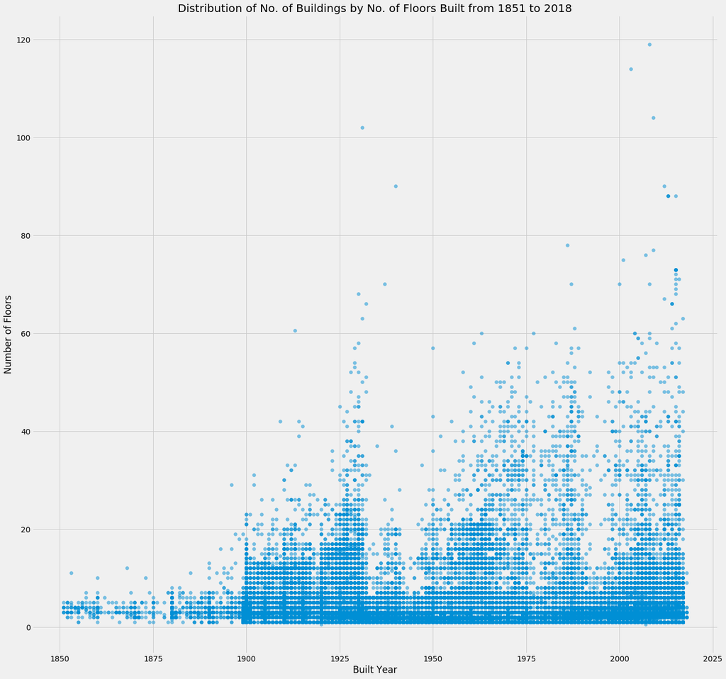

```python
plt.figure(figsize=(20,20))
plt.scatter(copy['YearBuilt'], copy['NumFloors'], alpha=0.5)
plt.xlabel("Built Year")
plt.ylabel("Number of Floors")
plt.title('Distribution of No. of Buildings by No. of Floors Built from 1851 to 2018')
plt.show()
```

> The scatter plot illustrates the general distribution of a number of buildings by NumFloors built each year. In the chart, we can see that the low floor buildings are very dense and that high floors/skyscrapers are more like to be outliers. We first cut the bin per 10, and combine 50~120 as one bin to improve the visibility.

```python
bins = [0, 10, 20, 30, 40, 50, np.inf]
labels = ['0-9', '10-19', '20-29', '30-39', '40-49', '50-120']
copy['NumFloorsGroup'] = pd.cut(copy['NumFloors'], bins=bins, labels=labels, include_lowest=True)
```

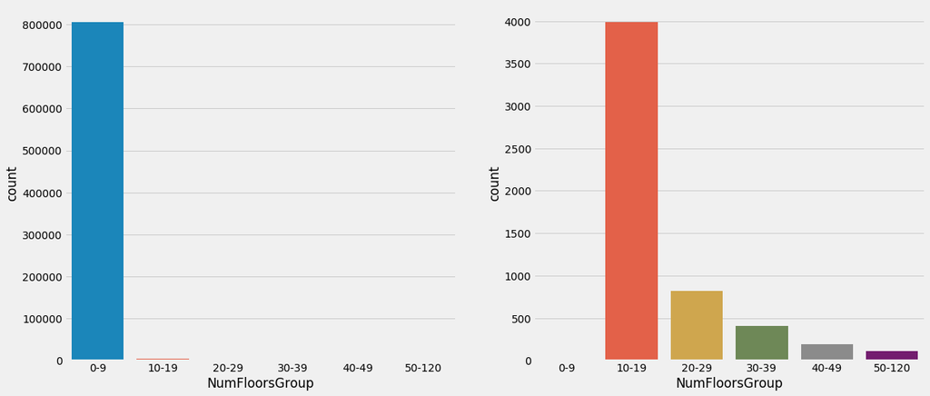

```python
figure, (ax1, ax2) = plt.subplots(nrows=1, ncols=2)
figure.set_size_inches(18, 8)

# Countplot of Number Of Buildings By Stories 0-9 vs the rest over the years
sns.countplot(x='NumFloorsGroup',data=copy, ax = ax1)
sns.countplot(x='NumFloorsGroup',data=copy[copy['NumFloorsGroup'] != '0-9'], ax = ax2)
```

> Observing the 2 plots above, we can confirm that 0-9 floors cover more than 90% of the dataset, thus comparing them separately and/or applying log scale for the number of buildings is inevitable.

```python
# Create another column Category to divide into LowFl 0~19, MiddleFl 20~49 and HighFl of the rest.
copy['Category'] = pd.cut(copy['NumFloors'],
                        bins=[0, 19, 50, np.inf],
                        labels=['LowFl','MiddleFl','HighFl'],
                        include_lowest=True)
```

```python
# Summarise the value counts by year
g = (copy.groupby(['YearBuilt', 'NumFloorsGroup'])['YearBuilt']
        .count()
        .reset_index(name="Count")
                 .sort_values(by='Count', ascending=False))
print(g.shape)
g.head()
```

```
(596, 3)
```

|  | YearBuilt | NumFloorsGroup | Count |
| --- | --- | --- | --- |
| 128 | 1920 | 0-9 | 90956 |
| 171 | 1930 | 0-9 | 76659 |
| 144 | 1925 | 0-9 | 70387 |
| 237 | 1950 | 0-9 | 47237 |
| 91 | 1910 | 0-9 | 46384 |

```python
# We create the `YearBuiltDecade` for different type of visualization later.
copy['YearBuiltDecade'] = (np.ceil(copy['YearBuilt'] / 10.0).astype(int) * 10)

e = (copy.groupby(['YearBuiltDecade', 'NumFloorsGroup'])['YearBuiltDecade']
        .count()
        .reset_index(name="Count")
                 .sort_values(by='Count', ascending=False))
print(e.shape)
e.head()
```

```
(81, 3)
```

|  | YearBuiltDecade | NumFloorsGroup | Count |
| --- | --- | --- | --- |
| 21 | 1930 | 0-9 | 165106 |
| 15 | 1920 | 0-9 | 111133 |
| 27 | 1940 | 0-9 | 101145 |
| 10 | 1910 | 0-9 | 82404 |
| 33 | 1950 | 0-9 | 75559 |

```python
# Let's categorize the `NumFloors` to High-Middle-Low groups to both summary data `g` and copy data `copy`
d = { "0-9": 'LowFl',  "10-19": 'LowFl', "50-120": 'HighFl'}
g['Category']  = g['NumFloorsGroup'].map(d).fillna('MiddleFl')
copy['Category']  = copy['NumFloorsGroup'].map(d).fillna('MiddleFl')
```

```python
print(g.shape)
g.head()
```

```
(596, 4)
```

|  | YearBuilt | NumFloorsGroup | Count | Category |
| --- | --- | --- | --- | --- |
| 128 | 1920 | 0-9 | 90956 | LowFl |
| 171 | 1930 | 0-9 | 76659 | LowFl |
| 144 | 1925 | 0-9 | 70387 | LowFl |
| 237 | 1950 | 0-9 | 47237 | LowFl |
| 91 | 1910 | 0-9 | 46384 | LowFl |

```python
g.groupby('NumFloorsGroup')['Category'].count()
```

```
NumFloorsGroup
0-9       168
10-19     130
20-29     105
30-39      80
40-49      67
50-120     46
Name: Category, dtype: int64
```

> This convinces the binning strategy works.

```python
g.groupby('Category')['Count'].count()
```

```
Category
HighFl       46
LowFl       298
MiddleFl    252
Name: Count, dtype: int64
```

> This summary also could work depending on the requirements of visualization.

```python
# Log transform the count value
g['LogCount'] = np.log(g['Count'])
```

```python
g.head()
```

|  | YearBuilt | NumFloorsGroup | Count | Category | LogCount |
| --- | --- | --- | --- | --- | --- |
| 128 | 1920 | 0-9 | 90956 | LowFl | 11.418131 |
| 171 | 1930 | 0-9 | 76659 | LowFl | 11.247122 |
| 144 | 1925 | 0-9 | 70387 | LowFl | 11.161764 |
| 237 | 1950 | 0-9 | 47237 | LowFl | 10.762933 |
| 91 | 1910 | 0-9 | 46384 | LowFl | 10.744710 |

```python
copy2 = copy.loc[:,['YearBuilt', 'NumFloors', 'NumFloorsGroup', 'Category']]
copy2_g = (copy2.groupby(['YearBuilt', 'NumFloorsGroup', 'Category', 'NumFloors'])['YearBuilt']
        .count()
        .reset_index(name="Count")
                 .sort_values(by='Count', ascending=False))
print(copy2_g.shape)
copy2_g['LogCount'] = np.log(copy2_g['Count'])
copy2_g.head()
```

```
(4184, 5)
```

|  | YearBuilt | NumFloorsGroup | Category | NumFloors | Count | LogCount |
| --- | --- | --- | --- | --- | --- | --- |
| 825 | 1920 | 0-9 | LowFl | 2.0 | 48197 | 10.783052 |
| 1199 | 1930 | 0-9 | LowFl | 2.0 | 43718 | 10.685515 |
| 976 | 1925 | 0-9 | LowFl | 2.0 | 40561 | 10.610562 |
| 1505 | 1940 | 0-9 | LowFl | 2.0 | 24926 | 10.123667 |
| 1722 | 1950 | 0-9 | LowFl | 2.0 | 23712 | 10.073737 |

```python
import warnings
warnings.simplefilter('ignore', UserWarning)

plt.figure(figsize=(18,16))

fig = ff.create_facet_grid(
    copy2_g,
    x='YearBuilt',
    y='LogCount',
    facet_row='NumFloorsGroup',
    color_name='NumFloorsGroup',
    color_is_cat = True,
    marker={'color': 'rgb(86, 7, 100)'},
    trace_type='histogram',
    height=800, width=800
)
py.iplot(fig, filename='Histogram of No. of Buildings(log) by No. of Floors Built from 1851 to 2018')
```

[interactive chart not shown]

> The subplots above show log count of buildings according to the pre-defined bins. However, despite sharing the x-axis and y-axis, this is somewhat inefficient due to the size of the bar and the difference gap on y-axis.

```python
import warnings
warnings.simplefilter('ignore', UserWarning)

plt.figure(figsize=(18,16))

fig = ff.create_facet_grid(
    copy2_g,
    x='YearBuilt',
    y='LogCount',
    facet_row='NumFloorsGroup',
    color_name='NumFloorsGroup',
    color_is_cat = True,
    marker={'color': 'rgb(86, 7, 100)'},
    height=800, width=800

)
py.iplot(fig, filename='Distribution of No. of Buildings(log) by No. of Floors Built from 1851 to 2018')
```

[interactive chart not shown]

> The scatter subplots above show the density of the number of floors of buildings built per year. Scatter plot does show the distribution very well.

```python
t1 = g[g['NumFloorsGroup'] == '0-9']
t2 = g[g['NumFloorsGroup'] == '10-19']
t3 = g[g['NumFloorsGroup'] == '20-29']
t4 = g[g['NumFloorsGroup'] == '30-39']
t5 = g[g['NumFloorsGroup'] == '40-49']
t6 = g[g['NumFloorsGroup'] == '50-120']

dt1 = []
for i in range(0, len(t1.columns)):
    trace = go.Bar(
        x = t1[t1.columns[i]].index,
        y = t1[t1.columns[i]],
        name=t1.columns[i]
    )
    dt1.append(trace)

dt2 = []
for i in range(0, len(t2.columns)):
    trace = go.Bar(
        x = t2[t2.columns[i]].index,
        y = t2[t2.columns[i]],
        name=t2.columns[i]
    )
    dt2.append(trace)

dt3 = []
for i in range(0, len(t3.columns)):
    trace = go.Bar(
        x = t3[t3.columns[i]].index,
        y = t3[t3.columns[i]],
        name=t3.columns[i]
    )
    dt3.append(trace)

dt4 = []
for i in range(0, len(t4.columns)):
    trace = go.Bar(
        x = t4[t4.columns[i]].index,
        y = t4[t4.columns[i]],
        name=t4.columns[i]
    )
    dt4.append(trace)

dt5 = []
for i in range(0, len(t5.columns)):
    trace = go.Bar(
        x = t5[t5.columns[i]].index,
        y = t5[t5.columns[i]],
        name=t5.columns[i]
    )
    dt5.append(trace)

dt6 = []
for i in range(0, len(t3.columns)):
    trace = go.Bar(
        x = t6[t6.columns[i]].index,
        y = t6[t6.columns[i]],
        name=t6.columns[i]
    )
    dt6.append(trace)

trace1 = go.Bar(
    x=dt1[0]['y'],
    y=dt1[4]['y'],
    name = '0-9'
)
trace2 = go.Bar(
    x=dt2[0]['y'],
    y=dt2[4]['y'],
    name = '10-19'
)
trace3 = go.Bar(
    x=dt3[0]['y'],
    y=dt3[4]['y'],
    name = '20-29'
)

trace4 = go.Bar(
    x=dt4[0]['y'],
    y=dt4[4]['y'],
    name = '30-39'
)
trace5 = go.Bar(
    x=dt5[0]['y'],
    y=dt5[4]['y'],
    name = '40-49'
)
trace6 = go.Bar(
    x=dt6[0]['y'],
    y=dt6[4]['y'],
    name = '50-120'
)

fig = tools.make_subplots(rows=6, cols=1, specs=[[{}], [{}], [{}], [{}], [{}], [{}]],
                          shared_xaxes=True, shared_yaxes=True,
                          vertical_spacing=0.01)
fig.append_trace(trace1, 1, 1)
fig.append_trace(trace2, 2, 1)
fig.append_trace(trace3, 3, 1)
fig.append_trace(trace4, 4, 1)
fig.append_trace(trace5, 5, 1)
fig.append_trace(trace6, 6, 1)

fig['layout'].update(height=600, width=800, title='No. of Buildings by No. of Floors(log) Built from 1851 to 2018')
py.iplot(fig, filename='stacked-subplots-shared-xaxes')
```

```
This is the format of your plot grid:
[ (1,1) x1,y1 ]
[ (2,1) x1,y2 ]
[ (3,1) x1,y3 ]
[ (4,1) x1,y4 ]
[ (5,1) x1,y5 ]
[ (6,1) x1,y6 ]
```

[interactive chart not shown]

> The bar subplots above are a lot more detailed than the other histogram created previously.

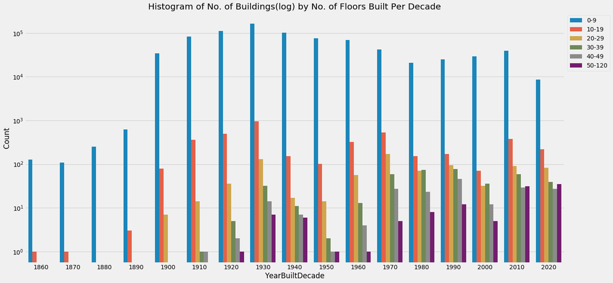

```python
plt.figure(figsize=(20,10))
barpl = sns.barplot(x="YearBuiltDecade", y="Count", hue="NumFloorsGroup", data=e)
barpl.set_yscale("log")
barpl.legend_.remove()
plt.legend(loc="upper left", bbox_to_anchor=(1,1))
plt.title("Histogram of No. of Buildings(log) by No. of Floors Built Per Decade")
plt.show()
```

> As we binned the Numfloors, dividing the year built as decade seems as efficient for clear visibility. As above, positioning the number of floors all at once within a decade to compare the trends help audiences to understand as both x-axis and y-axis share the same value.

## Part 2: Datashader

Datashader is a library from Anaconda that does away with the need for binning data. It takes in all of your datapoints, and based on the canvas and range returns a pixel-by-pixel calculations to come up with the best representation of the data. In short, this completely eliminates the need for binning your data.

As an example, lets continue with our question above and look at a 2D histogram of YearBuilt vs NumFloors:

```python
yearbins = 200
floorbins = 200

yearBuiltCut = pd.cut(ny['YearBuilt'], np.linspace(ny['YearBuilt'].min(), ny['YearBuilt'].max(), yearbins))
numFloorsCut = pd.cut(ny['NumFloors'], np.logspace(1, np.log(ny['NumFloors'].max()), floorbins))

xlabels = np.floor(np.linspace(ny['YearBuilt'].min(), ny['YearBuilt'].max(), yearbins))
ylabels = np.floor(np.logspace(1, np.log(ny['NumFloors'].max()), floorbins))

data = [
    go.Heatmap(z = ny.groupby([numFloorsCut, yearBuiltCut])['BBL'].count().unstack().fillna(0).values,
              colorscale = 'Greens', x = xlabels, y = ylabels)
]

py.iplot(data, filename = 'datashader-2d-hist')
```

[interactive chart not shown]

This shows us the distribution, but it's subject to some biases discussed in the Anaconda notebook [Plotting Perils](https://anaconda.org/jbednar/plotting_pitfalls/notebook).

Here is what the same plot would look like in datashader:

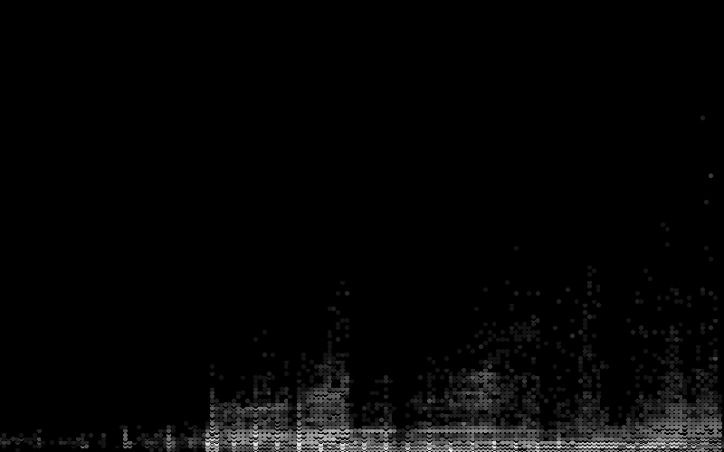

```python
cvs = ds.Canvas(800, 500, x_range = (ny['YearBuilt'].min(), ny['YearBuilt'].max()),
                                y_range = (ny['NumFloors'].min(), ny['NumFloors'].max()))
agg = cvs.points(ny, 'YearBuilt', 'NumFloors')
view = tf.shade(agg, cmap = cm(Greys9), how='log')
export(tf.spread(view, px=2), 'yearvsnumfloors')
```

That's technically just a scatterplot, but the points are smartly placed and colored to mimic what one gets in a heatmap. Based on the pixel size, it will either display individual points, or will color the points of denser regions.

Datashader really shines when looking at geographic information. Here are the latitudes and longitudes of our dataset plotted out, giving us a map of the city colored by density of structures:

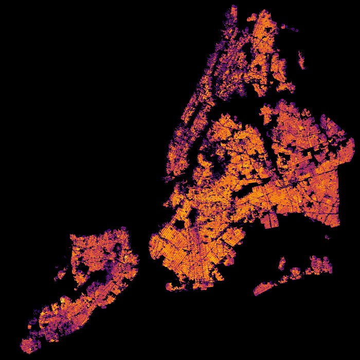

```python
NewYorkCity   = (( -74.29,  -73.69), (40.49, 40.92))
cvs = ds.Canvas(700, 700, *NewYorkCity)
agg = cvs.points(ny, 'lon', 'lat')
view = tf.shade(agg, cmap = cm(inferno), how='log')
export(tf.spread(view, px=2), 'firery')
```

Interestingly, since we're looking at structures, the large buildings of Manhattan show up as less dense on the map. The densest areas measured by number of lots would be single or multi family townhomes.

Unfortunately, Datashader doesn't have the best documentation. Browse through the examples from their [github repo](https://github.com/bokeh/datashader/tree/master/examples). I would focus on the [visualization pipeline](https://anaconda.org/jbednar/pipeline/notebook) and the [US Census](https://anaconda.org/jbednar/census/notebook) Example for the question below. Feel free to use my samples as templates as well when you work on this problem.

### Question

You work for a real estate developer and are researching underbuilt areas of the city. After looking in the [Pluto data dictionary](https://www1.nyc.gov/assets/planning/download/pdf/data-maps/open-data/pluto_datadictionary.pdf?v=17v1_1), you've discovered that all tax assessments consist of two parts: The assessment of the land and assessment of the structure. You reason that there should be a correlation between these two values: more valuable land will have more valuable structures on them (more valuable in this case refers not just to a mansion vs a bungalow, but an apartment tower vs a single family home). Deviations from the norm could represent underbuilt or overbuilt areas of the city. You also recently read a really cool blog post about [bivariate choropleth maps](http://www.joshuastevens.net/cartography/make-a-bivariate-choropleth-map/), and think the technique could be used for this problem.

Datashader is really cool, but it's not that great at labeling your visualization. Don't worry about providing a legend, but provide a quick explanation as to which areas of the city are overbuilt, which areas are underbuilt, and which areas are built in a way that's properly correlated with their land value.

```python
assess_dt = ny[['AssessTot', 'AssessLand','lon','lat']].copy()
print(ny.shape)
print(assess_dt.shape)
```

```
(811134, 91)
(811134, 4)
```

```python
# Create column `AssessBldg`: Assessment Value, Building
assess_dt['AssessBldg'] = assess_dt['AssessTot'].sub(assess_dt['AssessLand'], axis=0)
assess_dt.drop('AssessTot', axis = 1, inplace = True)
assess_dt = assess_dt[['AssessLand', 'AssessBldg', 'lon', 'lat']]
print(assess_dt.shape)
assess_dt.head()
```

```
(811134, 4)
```

|  | AssessLand | AssessBldg | lon | lat |
| --- | --- | --- | --- | --- |
| 1 | 834300 | 12946500 | -73.987066 | 40.704619 |
| 16 | 129600 | 300600 | -73.989310 | 40.704109 |
| 19 | 178200 | 35550 | -73.990608 | 40.704581 |
| 21 | 514350 | 7792650 | -73.988008 | 40.704131 |
| 22 | 972000 | 42006600 | -73.987077 | 40.704101 |

```python
# In order to use the bivariate choropleth map, we must normalize our data.
# We will divide the two columns into three percentile classes, with breakpoints n/3 percentile.
# That way the unibariate categories (3(2) = 6) are combined into (3^2=9) bivariate categories.

p = 100 / 3 # underbuilt, norm, and overbuilt percentile bins
q = np.percentile(assess_dt[['AssessLand', 'AssessBldg']], [p, 100 - p], axis=0) # breakpoints

# Define the bin by classifying the data
# Mark cells in horizontal order with A, B, or C.
# Then mark the cells in vertical order with 1, 2, or 3
assess_dt['Land_Class'] = pd.cut(assess_dt['AssessLand'], [0, q[0][0], q[1][0], np.inf], right=False, labels=['A', 'B', 'C'])
assess_dt['Bldg_Class'] = pd.cut(assess_dt['AssessBldg'], [0, q[0][1], q[1][1], np.inf], right=False, labels=['1', '2', '3'])
```

```python
assess_dt.head()
```

|  | AssessLand | AssessBldg | lon | lat | Land_Class | Bldg_Class |
| --- | --- | --- | --- | --- | --- | --- |
| 1 | 834300 | 12946500 | -73.987066 | 40.704619 | C | 3 |
| 16 | 129600 | 300600 | -73.989310 | 40.704109 | C | 3 |
| 19 | 178200 | 35550 | -73.990608 | 40.704581 | C | 3 |
| 21 | 514350 | 7792650 | -73.988008 | 40.704131 | C | 3 |
| 22 | 972000 | 42006600 | -73.987077 | 40.704101 | C | 3 |

```python
assess_dt['Co_Class'] = (assess_dt['Land_Class'].astype(str) + assess_dt['Bldg_Class'].astype(str)).astype('category')
assess_dt['Co_Class'].value_counts()
```

```
C3    176070
A1    127324
B2    114413
B1    106444
A2     98241
C2     57821
B3     49576
A3     44750
C1     36495
Name: Co_Class, dtype: int64
```

```python
# Color Palette from the example. We will use the first one.

from IPython.display import Image
from IPython.core.display import HTML
Image(url= "http://www.joshuastevens.net/images/js_bivariatePalettes.png")
```

[figure not shown]

```python
colors = {'A1': '#e8e8e8', 'A2': '#b0d5df', 'A3': '#64acbe',
          'B1': '#e4acac', 'B2': '#ad9ea5', 'B3': '#627f8c',
          'C1': '#c85a5a', 'C2': '#985356', 'C3': '#574249'}

NYC = ((-74.29,  -73.69), (40.49, 40.92))

cvs = ds.Canvas(700, 700, *NYC)
agg = cvs.points(assess_dt, 'lon', 'lat', ds.count_cat('Co_Class'))
```

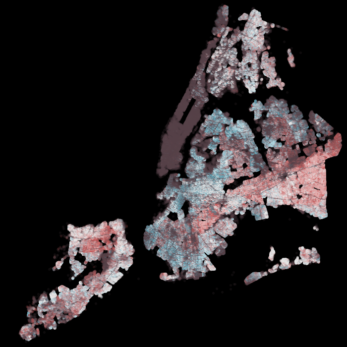

```python
view = tf.shade(agg, color_key = colors)
export(tf.spread(view, px=2), 'cloropleth_map')
```

> The overbuilt biuldings are shown in light blue color illustrating the higher building value. The underbuilt buildings are shown in light red color. This illustrates the higher land value.